# Sociología del Género

SOL3061 | C2. Género a nivel micro: individuos e ideas

Tania Hutt

## Nivel Micro

- El cuerpo
- La socialización
- Las identidades

## El sistema sexo/género como estructura multinivel

- El género no es un atributo individual: es una **estructura social** (Risman, 2004).
- Opera simultáneamente en tres niveles:
  1. **Individual**: identidades, cuerpos, socialización, disposiciones.
  2. **Interaccional**: expectativas culturales, “hacer género” (*doing gender*).
  3. **Institucional**: leyes, organizaciones, distribución de recursos.
- Ridgeway y Saperstein (2024): el sexo/género funciona como un **“sistema multinivel”** que se refuerza a sí mismo.
- El género es un **marco primario** (*primary frame*) para la percepción de personas: lo primero que categorizamos al interactuar con alguien.

## Binarismo de género

**Hay dos tipos de personas, aquellas que tienen cuerpos de *hombre* y son *masculinos*, y aquellas que tienen cuerpos de *mujer* y son *femeninas*. Estos dos tipos son fundamentalmente *diferentes y opuestos*.**

**¿Cuáles son algunas implicancias del binarismo?**

## Consecuencias del binarismo para personas intersexuales

[video not shown]

[Ver en YouTube](https://www.youtube.com/watch?v=2S0e-i117vY)

## Fuera del binario

- El binarismo va más allá del sexo biológico: se espera que las personas se identifiquen claramente con un género binario.
  - Que una persona asignada de sexo “masculino” al nacer se identifique como hombre y se comporte según lo que socialmente definimos como “hombre”.
- Se estima que **más de 1/10 personas** reporte sentirse tan masculino como femenina, o más “atípico/a/e” que “típico/a/e” en su identidad de género.
- Ridgeway y Saperstein (2024): la **diversificación de categorías de género** (identidades trans, no binarias, género fluido) desafía el binarismo *pero* no necesariamente desmantela el sistema.
  - El marco primario binario sigue operando como base cognitiva en la interacción cotidiana.

## Discusión 1

[figure not shown]

**Si el binarismo funciona como un “marco primario” cognitivo (Ridgeway y Saperstein), ¿es posible desmantelarlo? ¿Qué implicancias tiene que la categorización por género sea automática e inconsciente para los esfuerzos por la igualdad de género?**

## Esencialismo de género

- El binarismo fortalece la idea de “opuestos”.
- Incentiva la **maximización de las diferencias** aparentes entre hombres y mujeres, haciendo el binarismo parecer más importante de lo que es.
- La realidad: hay mucho más en **común** que diferente entre hombres y mujeres.
- Connell (2009): el género no es una dicotomía fija, sino una **estructura de relaciones sociales** centrada en la arena reproductiva.

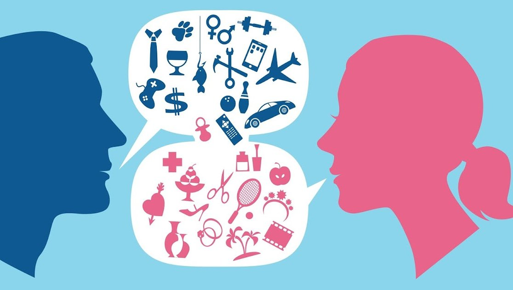

[This Photo](https://mercedesgallurm.blogspot.com/2019/11/los-roles-de-genero.html) by Unknown Author is licensed under [CC BY](https://creativecommons.org/licenses/by/3.0/)

## Diferencias y similitudes entre géneros

*El binarismo de género puede ser una construcción social, pero ¿hay diferencias **reales** entre hombres y mujeres?*

- Estudio de Zell et al. (2015): multisíntesis de estudios de diferencias entre sexos.
  - Combinaron más de 20,000 estudios
  - Muestra de 12 millones de personas
  - 21,000 mediciones de 386 atributos: pensamientos, emociones, comportamientos, habilidades intelectuales, estilos de comunicación, atributos de personalidad, medidas de felicidad y bienestar, habilidades físicas, etc.

## Resultados Zell et al. (2015)

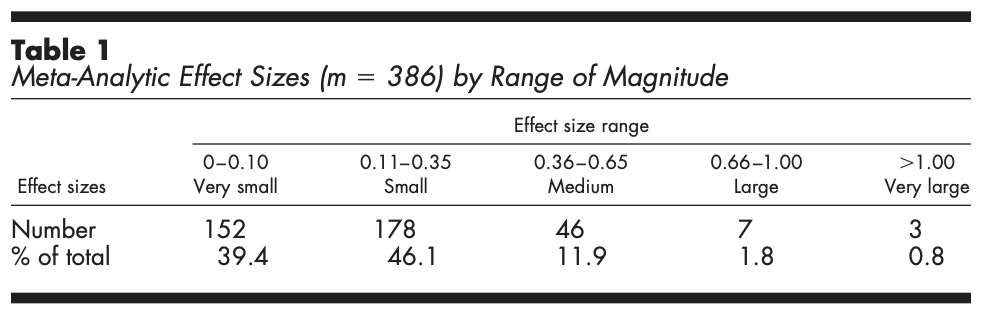

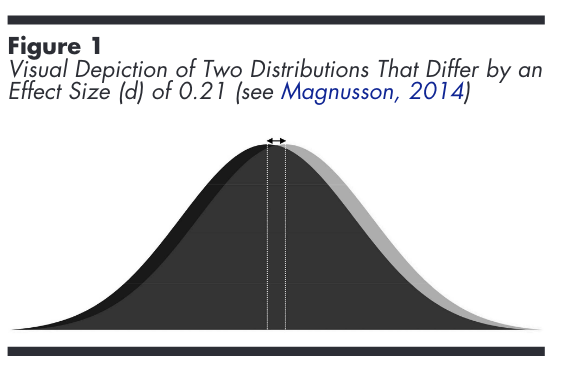

## Complicaciones con las teorías puramente biológicas

- Lo social afecta lo biológico (neuroplasticidad, epigenética).
- Lo social también afecta cómo **“vemos”** lo biológico.
  - Padres y madres perciben y explican de manera diferenciada los comportamientos de hijos e hijas, incluso cuando son idénticos.
- Los comportamientos diferenciados de cuidadorxs afectan el desarrollo cerebral.
- Connell (2009): los cuerpos son tanto agentes como objetos de la práctica social; no son una “base natural” sobre la cual se construye el género, sino parte del proceso mismo.

## La socialización de género: más allá de la familia

- Socialización: proceso por el cual la estructura de género se **internaliza** en la personalidad, preferencias y disposiciones.
- No se limita a la familia ni a la infancia:
  - Sistema educativo (currículum oculto)
  - Pares
  - Medios de comunicación
  - Instituciones religiosas, deportivas, etc.
- Socialización continúa a lo largo de toda la vida.
- Pregunta clave: ¿Qué tan estables son estas disposiciones? ¿Cómo se adoptan o resisten en la adultez?

## Generizando el cuerpo: el currículum oculto (Martin, 1998)

- Estudio etnográfico en **5 escuelas** de EE.UU.
- Las escuelas enseñan género a través del **control corporal diferenciado**:
  - Cómo sentarse, moverse, hablar, vestirse.
  - Las niñas son disciplinadas hacia **comportamientos formales**: piernas cruzadas, manos en el regazo, voz baja.
  - Los niños tienen más libertad para comportamientos **relajados**: despatarrados, ruidosos, ocupando espacio.
- Hallazgos clave:
  - **82%** de los comportamientos formales fueron de niñas.
  - **80%** de los comportamientos relajados fueron de niños.
  - A las niñas se les pedía hacer silencio **3 veces más** que a los niños.

## El cuerpo como sitio de producción de género

- Martin (1998): el género se **inscribe en el cuerpo** a través de prácticas cotidianas.
  - El vestido: disfraces de princesa restringen el movimiento; disfraces de superhéroe lo promueven.
  - El contacto físico: niñas aprenden a ser “suaves”, niños a ser “rudos”.
  - El espacio: niños ocupan más espacio físico que niñas.
- Estas prácticas corporales generan **disposiciones duraderas** (habitus generizado).
- Bourdieu: el cuerpo es un **sitio de inscripción** del orden social.
- Las personas no sólo *tienen* un género: lo **encarnan**.

## Normalizando la heterosexualidad (Martin, 2009)

- Estudio con **600 madres** de preescolares en EE.UU.
- Pregunta: ¿cómo las madres enseñan (o no) sobre sexualidad a sus hijxs pequeñxs?
- Hallazgo principal: las madres **asumen la heterosexualidad** de sus hijxs y la refuerzan activamente:
  - Hablan de “novias/os” y matrimonio futuro.
  - Hacen invisible la homosexualidad.
  - Leen cuentos sobre príncipes y princesas como si fueran neutrales.
- Tres estrategias de las madres ante la homosexualidad:
  1. **Prepararse para la posibilidad** (aceptación anticipada).
  2. **Esperar lo mejor** (que sea heterosexual, pero aceptar si no).
  3. **Prevenir activamente** (evitar “influencias” homosexuales).

## Discusión 2

[figure not shown]

**Martin (1998, 2009) muestra que el género se enseña a través de prácticas sutiles y cotidianas en la escuela y la familia. Pensando en sus propias experiencias: ¿qué prácticas de socialización de género recuerdan de su infancia? ¿Cuáles fueron más influyentes: las explícitas o las implícitas?**

## Identidades de género: más allá del binarismo (Ridgeway y Saperstein, 2024)

- La identidad de género es el sentido subjetivo de pertenecer a una categoría de género.
- Históricamente: dos opciones (hombre/mujer), alineadas con el sexo asignado.
- Cambio contemporáneo: **diversificación** de identidades:
  - Personas transgénero binarias (hombre trans, mujer trans).
  - Personas no binarias, género fluido, agénero.
- ¿Qué implica esto para el sistema de género?
  - Personas trans binarias: pueden ser **incorporadas** al sistema sin transformarlo.
  - Identidades no binarias: desafían la **lógica categorial** misma del sistema.

## La formación de la identidad de género

- Ridgeway y Saperstein (2024) proponen que la identidad de género se forma a través de:
  1. **Categorización social**: cómo nos clasifican lxs demás.
  2. **Identificación personal**: cómo nos sentimos en relación a las categorías disponibles.
  3. **Prácticas de género**: lo que hacemos, cómo nos presentamos (West y Zimmerman: *doing gender*).
- Tensión entre identidad personal y categorización social:
  - ¿Qué pasa cuando la identidad interna no coincide con la categorización externa?
  - La experiencia trans como reveladora de los mecanismos del sistema.

## Nota sobre interseccionalidad

[figure not shown]

Al hablar de todo esto estamos dejando en pausa otras categorías de opresión o desigualdad para enfocarnos en el género de manera bien amplia y binaria.

[figure not shown]

Esto no quiere decir que no existan otros ejes de opresión, o que haya homogeneidad de experiencias y privilegios dentro de cada grupo. Consideremos esto para la discusión.

## Síntesis: el nivel micro del sistema de género

- El género se **inscribe en los cuerpos** desde la primera infancia (Martin, 1998).
- Se **normaliza** a través de prácticas cotidianas aparentemente inocentes (Martin, 2009).
- Funciona como un **marco primario** de percepción social que es automático y difícil de desactivar (Ridgeway y Saperstein, 2024).
- Las diferencias entre sexos son, en su mayoría, **pequeñas o triviales** (Zell et al., 2015).
- El cuerpo no es una base natural sino un **sitio de práctica social** (Connell, 2009).
- Pregunta abierta: si el género opera a nivel micro de maneras tan profundas e inconscientes, ¿dónde están las posibilidades de cambio?